# Lab 1

Carmen Canedo

6 October 2020

# Exercise 1

Read in `avocadoes.csv` and save into data frame.

# Exercise 2

Change column names to small, large, and extra large.

# Excercise 3

The data is not tidy, I will need to use `pivot_longer()` to tidy it. The size variable is split into small, large, and extra large.

```
Error: Must subset columns with a valid subscript vector.
x Subscript has the wrong type `quosures`.
ℹ It must be numeric or character.
```

# Exercise 4

Create a function to read in the avocado data, renames columns, writes the transformed, and returns transformed data

# Exercise 5

# Exercise 6

Create a plot showing daily sales volume in California for different avocado types and sizes.

```
Error: `rows` must be `NULL` or a `vars()` list if `cols` is a `vars()` list
```

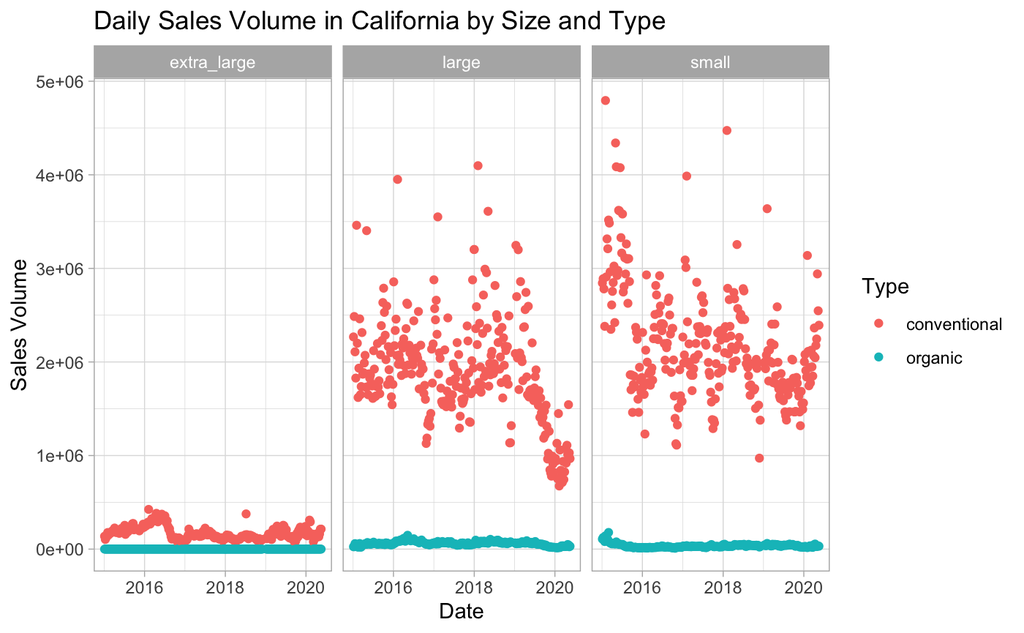

# Exercise 7

Load `heart.txt`

# Exercise 8

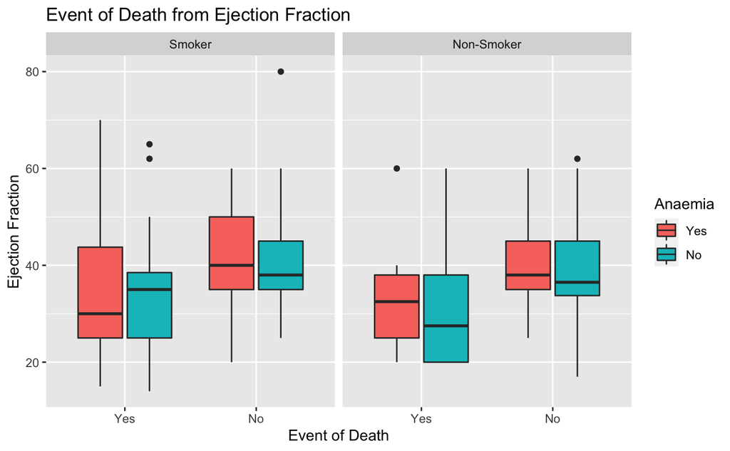

# Exercise 9

Create a segmented bar chart where the bars represent one of the factor variables and `DEATH_EVENT` is the fill.

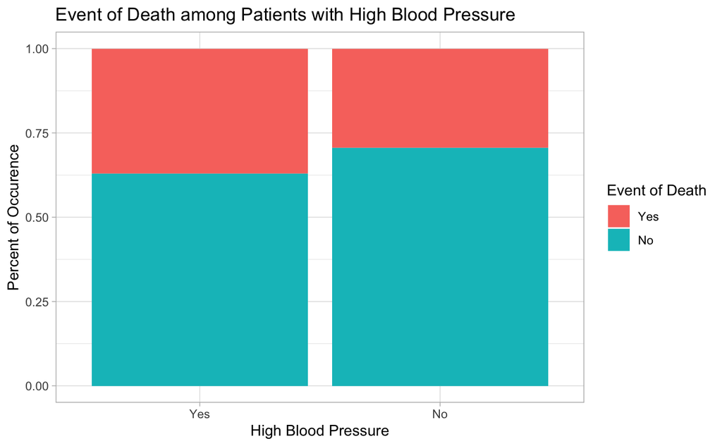

Takeaway: From this plot we can see that patients with high blood pressure are more likely to die than patients who did not have high blood pressure.

# Exercise 10

```
Error: Problem with `mutate()` input `num_events_cumulative`.
x argument of length 0
ℹ Input `num_events_cumulative` is `seq(1:nrow(heart$time))`.
```